# Tempo and mode of trait evolution

Natalie Cooper (natalie.cooper@nhm.ac.uk)

2018-02-07

# What are the tempo and mode of evolution?

- tempo = speed or rate of evolution
- mode = how evolution happens

# Tempo/rates of evolution

1. Only considering the phylogeny/species (*Tuesday*)
   - speciation rates
   - extinction rates
   - diversification rates
2. Considering the traits of the species
   - rates of trait evolution

# Models of evolution

1. Only considering the phylogeny/species
   - gradual evolution (*Darwin*)
   - punctuated equilibrium (*Eldredge & Gould 1979*)
   - diversity dependence (*Rabosky*)
2. Considering the traits of the species
   - models of trait evolution
   - Brownian motion, Ornstein Uhlenbeck, Early Burst etc.
   - Mk models

# Models of continuous trait evolution - BM

- Brownian motion model
- Trait $X$ evolves at random at a rate $\sigma$:

$dX(t) = \sigma dW(t)$

- $W(t)$ is a white noise function
  - random variate drawn from a normal distribution
  - mean = 0
  - variance = $\sigma^2$.

# Models of continuous trait evolution - BM

- assumes no overall drift in the direction of evolution
- assumes rate of evolution is constant
- often called a random walk
- close relatives will be more similar in their trait values than more distant relatives.
- variance in the trait will increase (linearly) in proportion to time.

# Models of continuous trait evolution - OU

- Ornstein-Uhlenbeck model
- random walk where trait values are pulled back an “optimal” value

$dX(t) = -\alpha(X(t) - \mu) + \sigma dW(t)$

- $\mu$ is a long-term mean species evolve around
- $\alpha$ is the strength of evolutionary force that returns traits back towards the long-term mean
  - “rubber band” parameter
  - if $\alpha$ is zero then evolution is Brownian.

# Models of continuous trait evolution - BM and OU

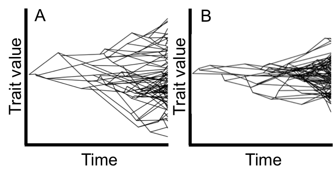

# Models of continuous trait evolution - EB

- Early Burst model
- random walk model where the rate of evolution decreases exponentially through time

$r(t) = \sigma^2e(at)$

- $r(t)$ is the rate of evolution at time $t$,
- $\sigma^2$ is the initial rate of evolution
- $a$ is the rate change parameter ($<=0$) .
  - if $a$ is negative, rates of evolution decrease through time
  - $a$ is zero then evolution is Brownian

# Models of continuous trait evolution

- SSP = OU with one optimum, it can have many.

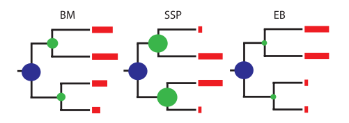

# Model selection - AIC

- is everyone happy with AIC?

# Models of discrete trait evolution

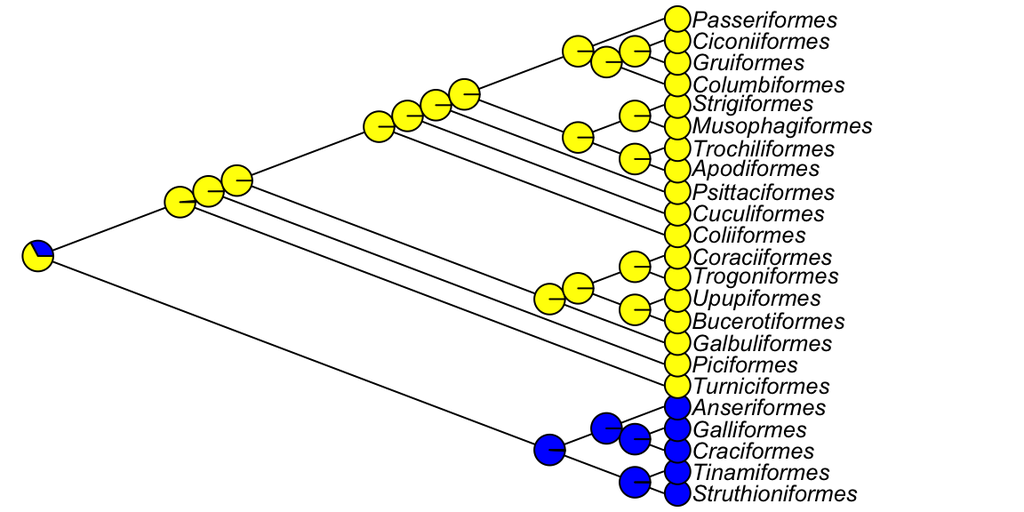

# Models of discrete trait evolution - ER

- Mk1 – all rates equal (ER)
  - M for Markov
  - k1 for $k = 1$ or 1 parameter.
- single transition rate (Q rate matrix).

| - | A | B | C |
| --- | --- | --- | --- |
| A | - | 1 | 1 |
| B | 1 | - | 1 |
| C | 1 | 1 | - |

- **Jukes-Cantor model**

# Models of discrete trait evolution - SYM

- Mk – symmetric rates (SYM)

| - | A | B | C |
| --- | --- | --- | --- |
| A | - | 1 | 2 |
| B | 1 | - | 3 |
| C | 2 | 3 | - |

- rate of change is the same regardless of direction
- rate of change differs among states
- **6-rate GTR (General Time Reversible) model**
- a symmetric model with only 2 states = equal rates (Mk1) model.

# Models of discrete trait evolution - ARD

- All rates different model (ARD)

| - | A | B | C |
| --- | --- | --- | --- |
| A | - | 1 | 2 |
| B | 3 | - | 4 |
| C | 5 | 6 | - |

- rate of change differs among states and directions
- good if you assume states are not reversible
- good for large complex datasets
- beware of over-fitting

# Practical - Macroevolutionary models in R

- split into two practicals - continuous and discrete traits
- may be more detail than you need, we’ll see how we get on
- make sure to read the notes carefully
- feel free to discuss with colleagues
- ask if you get stuck or have questions
- take breaks when you like
- Remember to answer the practice questions (on the discrete practical file) and SAVE YOUR RESULTS AND CODE.